# **Loan Default Prediction**

**Let's observe the feature importance of this model and try to analyze**

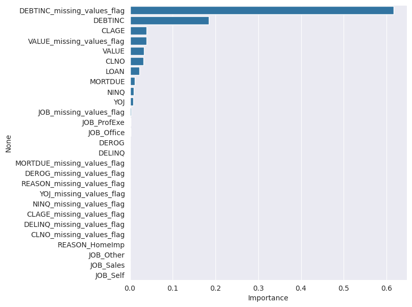

```python
importances = d_tree_tuned_rs.feature_importances_

columns = X.columns

importance_df = pd.DataFrame(importances, index = columns, columns = ['Importance']).sort_values(by = 'Importance', ascending = False)

plt.figure(figsize = (7, 7))

sns.barplot(x=importance_df.Importance,y= importance_df.index)
```

**Observations**:

Plot the random tree

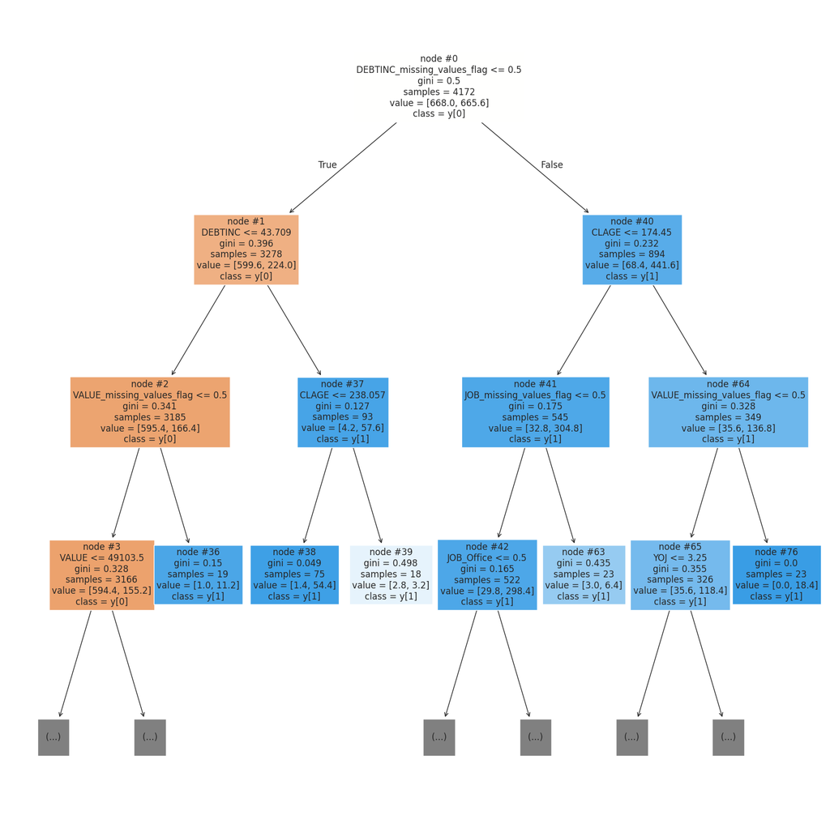

```python
# Plotting the decision  tree and analyze it to build the decision rule

features = list(X.columns)

plt.figure(figsize = (20, 20))

tree.plot_tree(d_tree_tuned_rs, max_depth = 3, feature_names = features, filled = True, fontsize = 12, node_ids = True, class_names = True)

plt.show()
```

**Observations**:

### **Building a Random Forest Classifier**

**Random Forest is a bagging algorithm where the base models are Decision Trees.** Samples are taken from the training data and on each sample a decision tree makes a prediction.

**The results from all the decision trees are combined together and the final prediction is made using voting or averaging.**

```python
# Defining Random forest CLassifier

rf_estimator = RandomForestClassifier(random_state = 1)

rf_estimator.fit(x_train, y_train)
```

```
RandomForestClassifier(random_state=1)
```

```python
#Checking performance on the training data

y_pred_train_rf = rf_estimator.predict(x_train)

metrics_score(y_train, y_pred_train_rf)
```

```
              precision    recall  f1-score   support

           0       1.00      1.00      1.00      3340
           1       1.00      1.00      1.00       832

    accuracy                           1.00      4172
   macro avg       1.00      1.00      1.00      4172
weighted avg       1.00      1.00      1.00      4172
```

```
              precision    recall  f1-score   support

           0       0.92      0.95      0.94      1431
           1       0.79      0.68      0.73       357

    accuracy                           0.90      1788
   macro avg       0.85      0.82      0.83      1788
weighted avg       0.90      0.90      0.90      1788
```

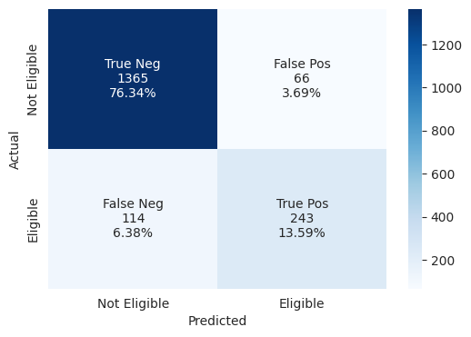

```python
# Checking performance on the test data

y_pred_test_rf = rf_estimator.predict(x_test)

metrics_score(y_test, y_pred_test_rf)
```

```python
rf_estimator_test = model_performance_classification(rf_estimator,x_test,y_test)
rf_estimator_test
```

|  | Precision | Recall | Accuracy |
| --- | --- | --- | --- |
| 1 | 0.79 | 0.68 | 0.90 |

Observations:

The Random Forest is giving a 100% score for all metrics on the training dataset.  
The Random Forest classifier seems to be overfitting the training data. The recall on the training data is 1, while the recall on the test data is only 68% for class 1.  
Precision is good for the test data- 79%

### **Random Forest Classifier Hyperparameter Tuning**

```python
# Defining Random Forest model with class weights class_weight={0: 0.2, 1: 0.8}
rf_estimator_balanced = RandomForestClassifier(class_weight = {0: 0.2, 1: 0.8}, random_state = 1)

# Fitting Random Forest model
rf_estimator_balanced.fit(x_train, y_train)
```

```
RandomForestClassifier(class_weight={0: 0.2, 1: 0.8}, random_state=1)
```

```python
# Checking performance on the train data

y_pred_train_rf = rf_estimator_balanced.predict(x_train)

metrics_score(y_train, y_pred_train_rf)
```

```
              precision    recall  f1-score   support

           0       1.00      1.00      1.00      3340
           1       1.00      1.00      1.00       832

    accuracy                           1.00      4172
   macro avg       1.00      1.00      1.00      4172
weighted avg       1.00      1.00      1.00      4172
```

```
              precision    recall  f1-score   support

           0       0.91      0.96      0.93      1431
           1       0.78      0.64      0.71       357

    accuracy                           0.89      1788
   macro avg       0.85      0.80      0.82      1788
weighted avg       0.89      0.89      0.89      1788
```

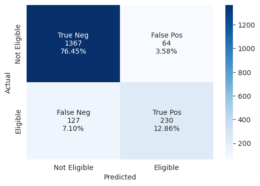

```python
# Checking performance on the test data

y_pred_test_rf = rf_estimator_balanced.predict(x_test)

metrics_score(y_test, y_pred_test_rf)
```

```python
rf_estimator_balanced_test = model_performance_classification(rf_estimator_balanced,x_test,y_test)
rf_estimator_balanced_test
```

|  | Precision | Recall | Accuracy |
| --- | --- | --- | --- |
| 1 | 0.78 | 0.64 | 0.89 |

**Observations**:

- The balanced random forest did not improve the model performance and also giving a 100% score for all metrics on the training dataset.
- It is also overfitting the training data. The recall on the training data is 1, while the recall on the test data is only 64% for class 1 compared to 68% in the baseline model
- Precision is good for the test data- 78%.

**Tuning the Random Forest**

**Using Grid search to perform hyperparameter tuning.** *Grid search is a tuning technique that attempts to compute the optimum values of hyperparameters.  
It is an exhaustive search that is performed on the specific parameter values of a model. The parameters of the estimator/model used to apply these methods are optimized by cross-validated grid-search over a parameter grid.

```python
# Choose the type of classifier
rf_estimator_tuned = RandomForestClassifier(criterion = "entropy", random_state = 7)

# Grid of parameters to choose from
parameters = {"n_estimators": [100, 110, 120],
    "max_depth": [5, 6, 7],
    "max_features": [0.8, 0.9, 1]
             }

# Type of scoring used to compare parameter combinations - recall score for class 1
scorer = metrics.make_scorer(recall_score, pos_label = 1)

# Run the grid search
grid_obj = GridSearchCV(rf_estimator_tuned, parameters, scoring = scorer, cv = 5)

grid_obj = grid_obj.fit(x_train, y_train)

# Set the classifier to the best combination of parameters
rf_estimator_tuned = grid_obj.best_estimator_
```

```python
# Fitting the best algorithm to the training data
rf_estimator_tuned.fit(x_train, y_train)
```

```
RandomForestClassifier(criterion='entropy', max_depth=6, max_features=0.9,
                       random_state=7)
```

```
              precision    recall  f1-score   support

           0       0.92      0.95      0.94      3340
           1       0.77      0.68      0.72       832

    accuracy                           0.90      4172
   macro avg       0.85      0.81      0.83      4172
weighted avg       0.89      0.90      0.89      4172
```

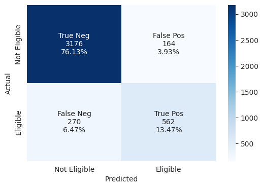

```python
# Checking performance on the train data

y_pred_train_rf = rf_estimator_tuned.predict(x_train)

metrics_score(y_train, y_pred_train_rf)
```

```
              precision    recall  f1-score   support

           0       0.91      0.95      0.93      1431
           1       0.75      0.61      0.67       357

    accuracy                           0.88      1788
   macro avg       0.83      0.78      0.80      1788
weighted avg       0.88      0.88      0.88      1788
```

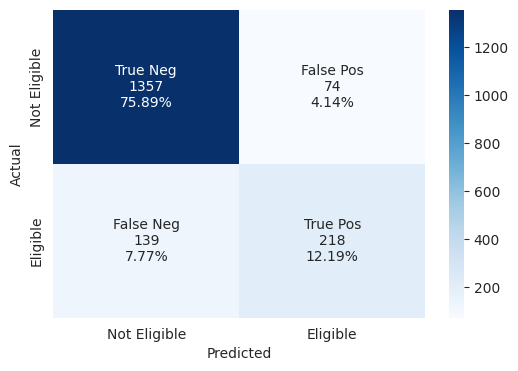

```python
# Checking performance on the test data

y_pred_test_rf = rf_estimator_tuned.predict(x_test)

metrics_score(y_test, y_pred_test_rf)
```

```python
rf_estimator_tuned_test = model_performance_classification(rf_estimator_tuned,x_test,y_test)
rf_estimator_tuned_test
```

|  | Precision | Recall | Accuracy |
| --- | --- | --- | --- |
| 1 | 0.75 | 0.61 | 0.88 |

**Observations**:

The tuned Random Forest model is less overfit than the untuned model.

However, the hyperparameter tuning with GridSearchCV, using the specified parameter grid and recall as the scoring metric, did not improve the model's ability to correctly identify actual defaulters on the test set (recall for Class 1). In fact, the recall for Class 1 decreased.

**Plotting the feature importance**

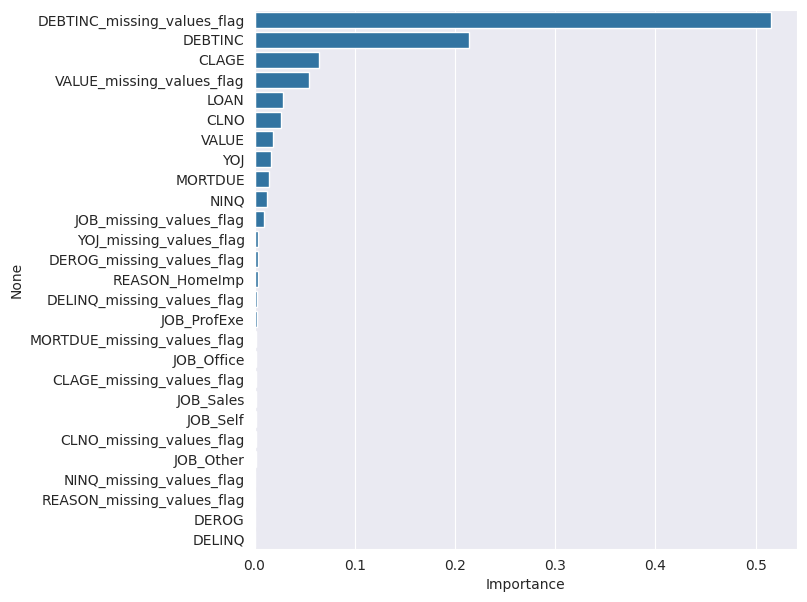

```python
# Checking performace on test dataset

importances = rf_estimator_tuned.feature_importances_

columns = X.columns

importance_df = pd.DataFrame(importances, index = columns, columns = ['Importance']).sort_values(by = 'Importance', ascending = False)

plt.figure(figsize = (7, 7))

sns.barplot(x=importance_df.Importance, y=importance_df.index)
```

# **Building XGBoost classifier**

```python
#Fitting XGBoost

xgb = XGBClassifier(random_state = 1, eval_metric = 'logloss')

# Fitting the model
xgb.fit(x_train,y_train)
```

```
XGBClassifier(base_score=None, booster=None, callbacks=None,
              colsample_bylevel=None, colsample_bynode=None,
              colsample_bytree=None, device=None, early_stopping_rounds=None,
              enable_categorical=False, eval_metric='logloss',
              feature_types=None, feature_weights=None, gamma=None,
              grow_policy=None, importance_type=None,
              interaction_constraints=None, learning_rate=None, max_bin=None,
              max_cat_threshold=None, max_cat_to_onehot=None,
              max_delta_step=None, max_depth=None, max_leaves=None,
              min_child_weight=None, missing=nan, monotone_constraints=None,
              multi_strategy=None, n_estimators=None, n_jobs=None,
              num_parallel_tree=None, ...)
```

```
              precision    recall  f1-score   support

           0       1.00      1.00      1.00      3340
           1       1.00      1.00      1.00       832

    accuracy                           1.00      4172
   macro avg       1.00      1.00      1.00      4172
weighted avg       1.00      1.00      1.00      4172
```

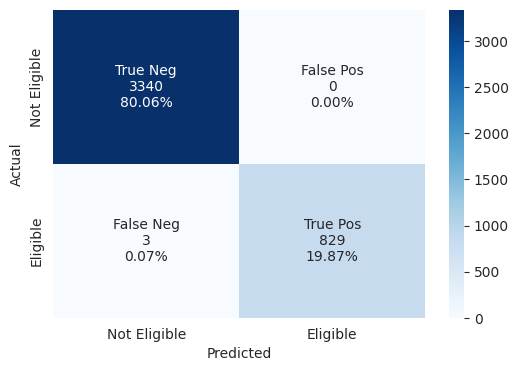

```python
y_pred_train_xgb = xgb.predict(x_train)

metrics_score(y_train, y_pred_train_xgb)
```

```
              precision    recall  f1-score   support

           0       0.92      0.97      0.94      1431
           1       0.83      0.66      0.73       357

    accuracy                           0.90      1788
   macro avg       0.88      0.81      0.84      1788
weighted avg       0.90      0.90      0.90      1788
```

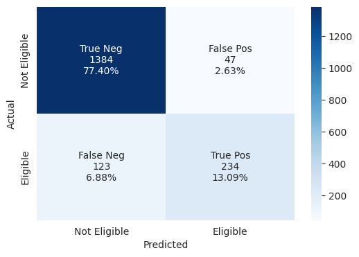

```python
y_pred_test_xgb = xgb.predict(x_test)

metrics_score(y_test, y_pred_test_xgb)
```

```python
# Model Performance on the test data
xgb_perf_test = model_performance_classification(xgb,x_test,y_test)

xgb_perf_test
```

|  | Precision | Recall | Accuracy |
| --- | --- | --- | --- |
| 1 | 0.83 | 0.66 | 0.90 |

**Observation**:

**1. Comparison of various techniques and their relative performance based on chosen Metric (Measure of success):**

- How do different techniques perform? Which one is performing relatively better? Is there scope to improve the performance further?

```python
def get_recall_score(model,flag=True,X_train=x_train,X_test=x_test):
    '''
    model : classifier to predict values of X

    '''
    a = [] # defining an empty list to store train and test results
    pred_train = model.predict(X_train)
    pred_test = model.predict(X_test)
    train_recall = metrics.recall_score(y_train,pred_train)
    test_recall = metrics.recall_score(y_test,pred_test)
    a.append(train_recall) # adding train recall to list
    a.append(test_recall) # adding test recall to list

    # If the flag is set to True then only the following print statements will be dispayed. The default value is set to True.
    if flag == True:
        print("Recall on training set : ",metrics.recall_score(y_train,pred_train))
        print("Recall on test set : ",metrics.recall_score(y_test,pred_test))

    return a # returning the list with train and test scores
```

```python
##  Function to calculate precision score
def get_precision_score(model,flag=True,X_train=x_train,X_test=x_test):
    '''
    model : classifier to predict values of X

    '''
    b = []  # defining an empty list to store train and test results
    pred_train = model.predict(X_train)
    pred_test = model.predict(X_test)
    train_precision = metrics.precision_score(y_train,pred_train)
    test_precision = metrics.precision_score(y_test,pred_test)
    b.append(train_precision) # adding train precision to list
    b.append(test_precision) # adding test precision to list

    # If the flag is set to True then only the following print statements will be dispayed. The default value is set to True.
    if flag == True:
        print("Precision on training set : ",metrics.precision_score(y_train,pred_train))
        print("Precision on test set : ",metrics.precision_score(y_test,pred_test))

    return b # returning the list with train and test scores
```

```python
##  Function to calculate accuracy score
def get_accuracy_score(model,flag=True,X_train=x_train,X_test=x_test):
    '''
    model : classifier to predict values of X

    '''
    c = [] # defining an empty list to store train and test results
    train_acc = model.score(X_train,y_train)
    test_acc = model.score(X_test,y_test)
    c.append(train_acc) # adding train accuracy to list
    c.append(test_acc) # adding test accuracy to list

    # If the flag is set to True then only the following print statements will be dispayed. The default value is set to True.
    if flag == True:
        print("Accuracy on training set : ",model.score(X_train,y_train))
        print("Accuracy on test set : ",model.score(X_test,y_test))

    return c # returning the list with train and test scores
```

```python
# Making the list of all the model names

models = [xgb,rf_estimator_tuned, rf_estimator_balanced, rf_estimator, random_search, dt]

# defining empty lists to add train and test results
acc_train = []
acc_test = []
recall_train = []
recall_test = []
precision_train = []
precision_test = []

# looping through all the models to get the accuracy,recall and precision scores
for model in models:

     # precision score
    l = get_precision_score(model,False)
    precision_train.append(l[0])
    precision_test.append(l[1])

    # accuracy score
    j = get_accuracy_score(model,False)
    acc_train.append(j[0])
    acc_test.append(j[1])

    # recall score
    k = get_recall_score(model,False)
    recall_train.append(k[0])
    recall_test.append(k[1])
```

```python
# Ensure the previous cell (BOYf1jL-zW2X) has been executed to populate the lists

# Mentioning the Model names in the list.
comparison_frame = pd.DataFrame({'Model':['XGBoost classifier','Tuned Random Forest', 'Balanced Random Forest','Random Forest','RandomizedSearchCV', 'Decision Tree'],
                                          'Train_Accuracy': acc_train,
                                          'Test_Accuracy': acc_test,
                                          'Train_Recall': recall_train,
                                          'Test_Recall': recall_test,
                                          'Train_Precision': precision_train,
                                          'Test_Precision': precision_test})

comparison_frame
```

|  | Model | Train_Accuracy | Test_Accuracy | Train_Recall | Test_Recall | Train_Precision | Test_Precision |
| --- | --- | --- | --- | --- | --- | --- | --- |
| 0 | XGBoost classifier | 1.00 | 0.90 | 1.00 | 0.66 | 1.00 | 0.83 |
| 1 | Tuned Random Forest | 0.90 | 0.88 | 0.68 | 0.61 | 0.77 | 0.75 |
| 2 | Balanced Random Forest | 1.00 | 0.89 | 1.00 | 0.64 | 1.00 | 0.78 |
| 3 | Random Forest | 1.00 | 0.90 | 1.00 | 0.68 | 1.00 | 0.79 |
| 4 | RandomizedSearchCV | 0.87 | 0.82 | 0.87 | 0.82 | 0.56 | 0.54 |
| 5 | Decision Tree | 1.00 | 0.86 | 1.00 | 0.59 | 1.00 | 0.66 |

```python
#Compare overall precision, recall, accuracy
models_test_comp_df = pd.concat(

    [
    lg_test.T, dtree.T, dtree_tuned_test.T,rf_estimator_test.T,
    rf_estimator_balanced_test.T, rf_estimator_tuned_test.T, xgb_perf_test.T, rscv_estimator_test.T
    ],

    axis = 1,
)

models_test_comp_df.columns = [
    "Logistic regresstion model",
    "Decision Tree classifier",
    "Tuned Decision Tree classifier (GridSearchCV)",
    "Random Forest classifier",
    "Balanced Random Forest classifier",
    "Tuned Random Forest classifier (GridSearchCV)",
    "XGBoost classifier",
    "Tuned Decision Tree classifier (RandomizedSearchCV)"
    ]
```

```python
print("Test performance comparison:")
models_test_comp_df.T
```

```
Test performance comparison:
```

|  | Precision | Recall | Accuracy |
| --- | --- | --- | --- |
| Logistic regresstion model | 0.72 | 0.59 | 0.87 |
| Decision Tree classifier | 0.66 | 0.59 | 0.86 |
| Tuned Decision Tree classifier (GridSearchCV) | 0.66 | 0.59 | 0.86 |
| Random Forest classifier | 0.79 | 0.68 | 0.90 |
| Balanced Random Forest classifier | 0.78 | 0.64 | 0.89 |
| Tuned Random Forest classifier (GridSearchCV) | 0.75 | 0.61 | 0.88 |
| XGBoost classifier | 0.83 | 0.66 | 0.90 |
| Tuned Decision Tree classifier (RandomizedSearchCV) | 0.54 | 0.82 | 0.82 |

**2. Refined insights:**

- What are the most meaningful insights relevant to the problem?

# **Model Interpretability check with Shapley Values**

```python
#Initialize Shap

# Need to load JS vis in the notebook
shap.initjs()
```

```python
#Local Interpretation using SHAP

explainer = shap.TreeExplainer(xgb)
shap_values = explainer.shap_values(x_train)
```

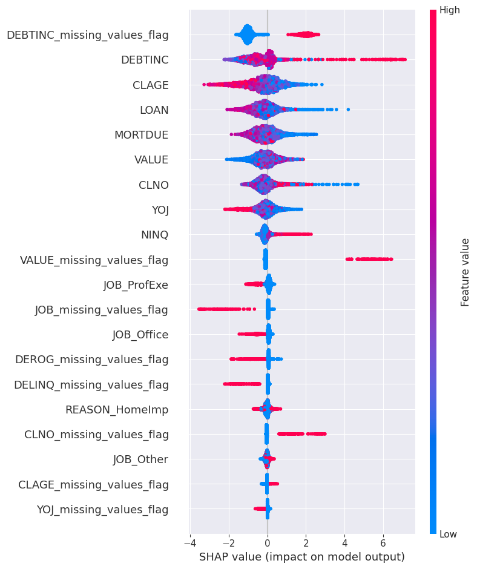

```python
shap.summary_plot(shap_values, features=x_train, feature_names=x_train.columns)
```

**Observations :**

The SHAP summary plot reinforces the importance of the debt-to-income ratio (DEBTINC) and, notably, the absence of this information (DEBTINC_missing_values_flag) in predicting loan default according to your XGBoost model. It also highlights the impact of other financial and credit history features.

**3. Proposal for the final solution design:**

- What model do you propose to be adopted? Why is this the best solution to adopt?

**Observations**:

High DEBTINC values are on the right side primarily because they contribute positively to identify defaulter. So, the prominent feature that is the most impactful in the change to default on a loan is the debt-to-income ratio.

# **Executive Summary**

# **Problem and solution summary**

- The prominent feature that is the most impactful in the change to default on a loan is the DEBTINC, but it is the one with the most missing data (21.3%) which is similar to the proportion of defaulted customers (20%) This emphasizes the impact of missing values on the prediction and should be communicated to the data entry team. A high debt-to-income ratio indicates that the applicant can not afford his/hers monthly mortgage payments, and having too much debt can be a sign of missing a payment or defaulting on the loan. The bank should consider this as a top feature to consider while processing a loan request.